# Machine Learning in Python: Exploring Table Data

### Violin Plots

The interpretation of the violin plots is similar to the box plots. However, since it is a 1-D KDE, the distributions are visible. The area of each violin is the same on each plot display. Looking at both box plots and the violin the certain similarities are observable. For example MeanAccX, the 'Acceleration-Ag' category of the box plot shows outliners, while in the violin plot they are included in the KDE distribution and the 'tail' is visible. The category 'Turn-Ag' in the box plot does not show any outliners but the wide range of the variables is observed in the 'long' violin plot.

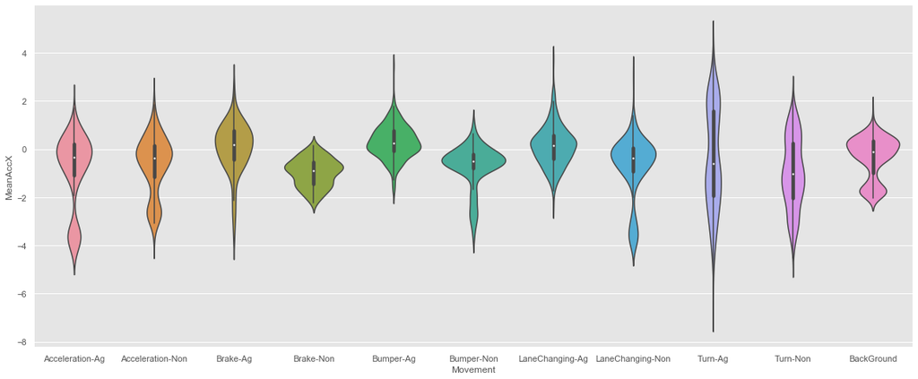

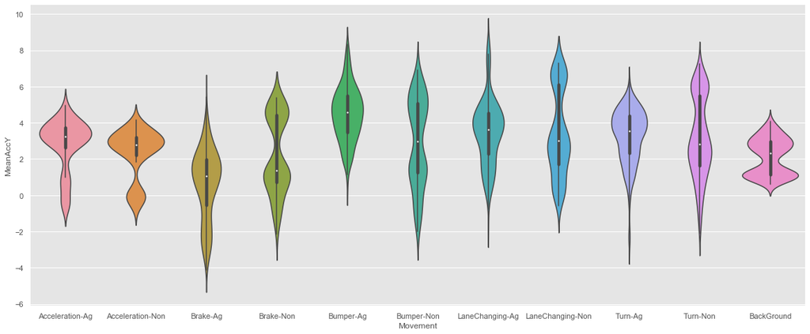

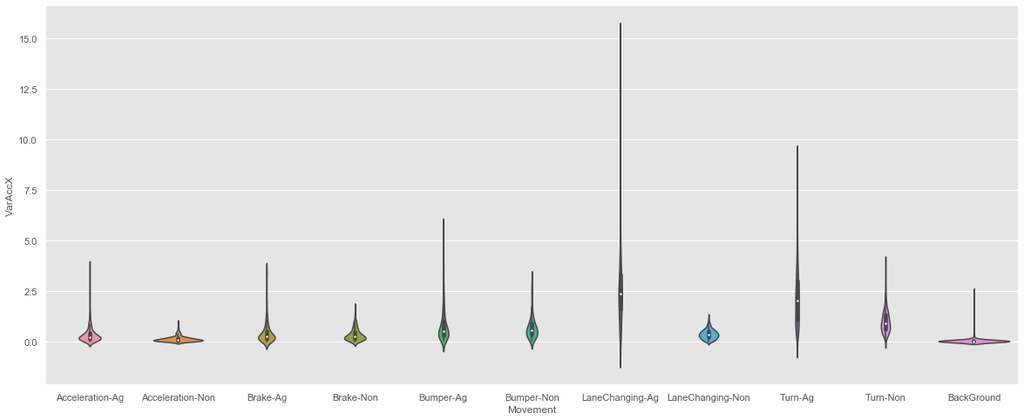

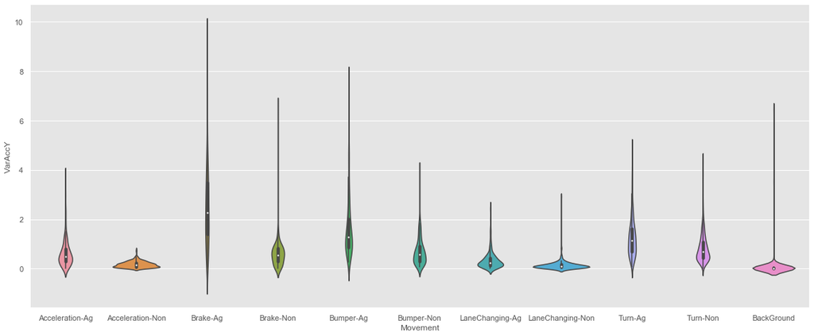

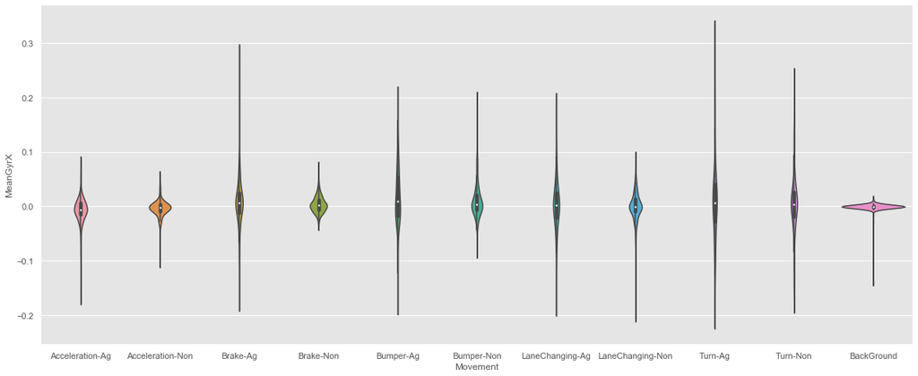

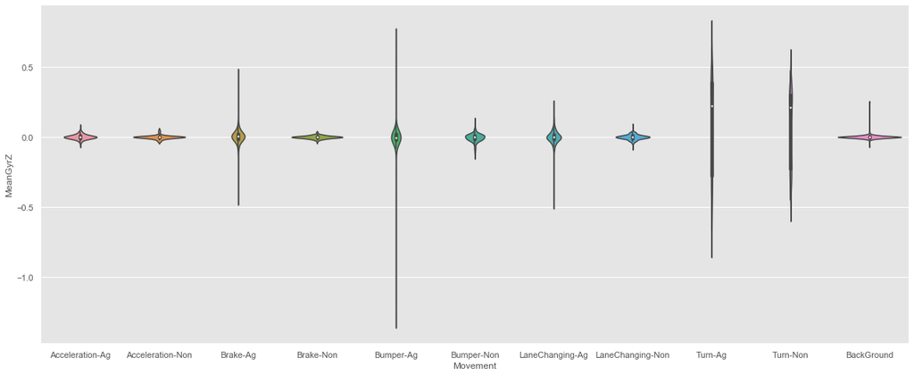

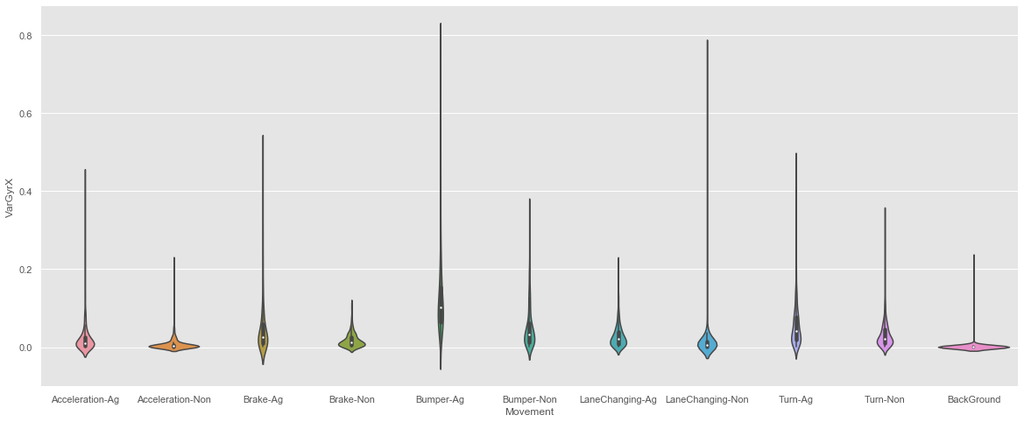

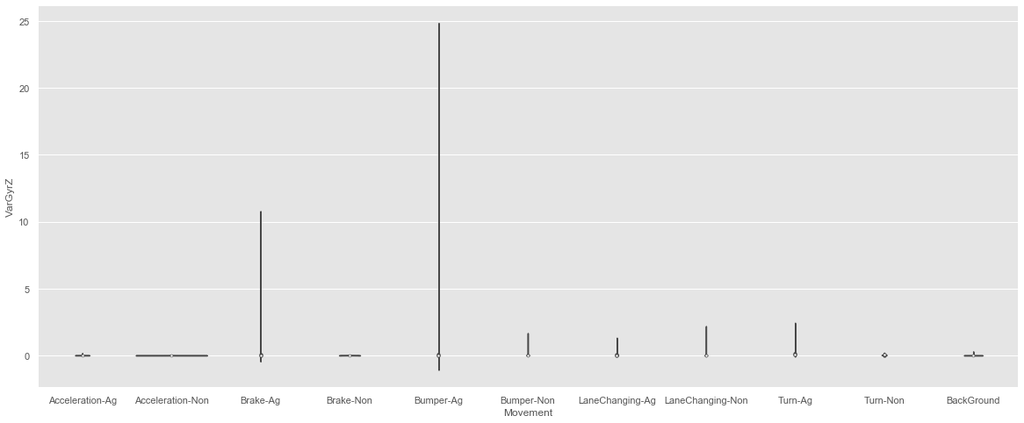

```python
column = ['MeanAccX', 'MeanAccY', 'VarAccX', 'VarAccY', 'MeanGyrX', 'MeanGyrZ', 'VarGyrX', 'VarGyrZ']
for col in column:
    plt.subplots(figsize=(20, 8))
    sns.violinplot(x="Movement", y=col, data=df)
```

## D. Exceptional Work

### Implementing dimensionality reduction using t-SNE

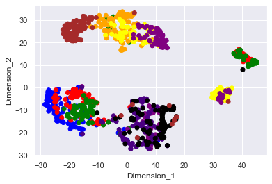

```python
n_sne = 900
label = column
color=['blue']*100+['red']*100+['green']*100+['orange']*100+['yellow']*100+['purple']*100+['indigo']*100+['black']*100+['brown']*100

# Fit and transform with a TSNE
from sklearn.manifold import TSNE
df= df.filter(['MeanAccX', 'MeanAccY', 'VarAccX', 'VarAccY', 'MeanGyrX', 'MeanGyrZ', 'VarGyrX', 'VarGyrZ', 'Ag_Non'], axis=1)
df[:n_sne]
X_2d = TSNE(n_components=2,n_iter = 500).fit_transform(df[:n_sne])
X_2d.shape

# Visualize the data
cmap = sns.set(style="darkgrid")
plt.scatter(X_2d[:, 0], X_2d[:, 1],color=color)
plt.xlabel('Dimension_1')
plt.ylabel('Dimension_2')
```

### Explanation of t-SNE dimensionality reduction methods

t-Distributed Stochastic Neighbor Embedding (t-SNE) is a non-linear technique for dimensionality reduction. When the dataset has many features it becomes difficult to understand or explore the relationships between the features as it is very difficult to visualize this high dimensional data. In such a case, we implement dimensionality reduction to convert this data to a 2 dimensional or 3-dimensional data in order to visualize it easily.

The algorithms start by calculating the probability of similarity of points in high-dimensional space and in the corresponding low-dimensional space. The similarity of points is calculated as the conditional probability that a point A would choose point B as its neighbor if neighbors were picked in proportion to their probability density under a Gaussian distribution which is centered at A. The difference between these conditional probabilities is then minimized in higher as well as lower dimension. This helps to represent data properly in lower dimensions.

t-Distributed stochastic neighbor embedding (t-SNE) minimizes the divergence between the distribution that measures pairwise similarities of the input data features and a distribution that measures pairwise similarities of the corresponding low-dimensional data points. It finds patterns in the data by identifying observed clusters based on the similarity of data points with multiple features. The input features, however, are not identifiable after doing dimensionality reduction using t-SNE so it is not possible to infer anything from the lower-dimensional data obtained from t-SNE. Thus, this process is mainly used for exploring and visualizing high dimensional data.

Above information about t-SNE is obtained from https://www.datacamp.com/community/tutorials/introduction-t-sne

## References:

based on: Eric Larson's course at SMU, Fall 2019, https://github.com/eclarson/MachineLearningNotebooks